# (Bike Ridership and Influencing Factors in San Francisco in 2017 )

## by: Bassam Faramawi

[figure not shown]

## Investigation Overview

In this investigation, I wanted to look at the characteristics of bike ridership in San Francisco in the 2nd half of 2017 and the factors that could influence it. The main focus was on the five factors: `Trip Duration`, `Member Age`, `Member Gender`, `User Type` and time of trip in terms of `Month`, `WeekDay` and `Hour` of day.

## Dataset Overview

The data consisted of trip durations and attributes of approximately 519,700 bike trips. The attributes included `duration_sec`, `member_birth_year`, `member_gender`, `user_type` and `start_time`&`end_time` features as well as additional measurements such as `bike_id`, `start_station_id`, and `end_station_id`.

## Distribution of Trip Durations

Trip durations in the dataset take on a large range of values, from about a 1 minute trip to about 1400 minute at the longest duration. Plotted on a logarithmic scale, the distribution of durations prices takes on a normal distribution shape with a spike of short durations between 6 and 20 minutes durations.

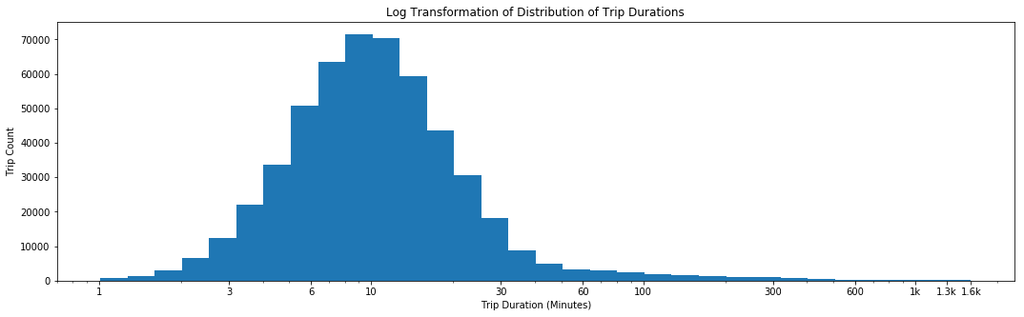

```python
# there's a long tail in the distribution, so let's put it on a log scale instead
log_binsize = 0.1
bins = 10 ** np.arange(np.log10(1.01), np.log10(gobike['duration_min'].max())+log_binsize, log_binsize)

plt.figure(figsize=[18, 5])
plt.hist(data = gobike, x = 'duration_min', bins = bins)
plt.xscale('log')
plt.xticks([1, 3, 6, 10, 30, 60, 100, 300, 600, 1000, 1300, 1600],
           [1, 3, 6, 10, 30, 60, 100, 300, 600, '1k', '1.3k', '1.6k'])
plt.xlabel('Trip Duration (Minutes)')
plt.ylabel('Trip Count')
plt.title('Log Transformation of Distribution of Trip Durations');
```

## Distribution of Members Ages

When investgating members ages, number of outliers points were identified. There is unbelievable (such as 1886 which his age in 2017 is 131 years), and by returning to **[this link](https://gerontology.wikia.org/wiki/List_of_oldest_living_people_in_the_United_States)** identifying this points be wrong entried so this points be imputated. The Distribution a semi-normal distribution with a peak between 25y and 35y old and a tail on the right with few trips associated with ages above 80y, I spotted on it's limits to view it more closely.

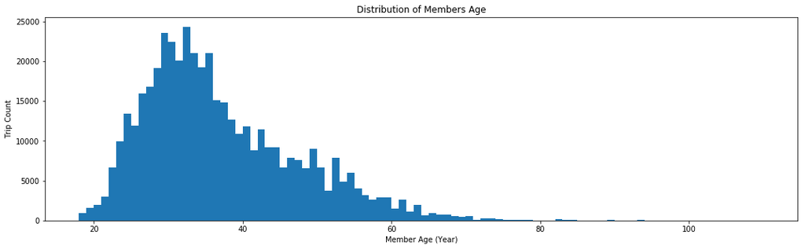

```python
# Plot hist of member_age
binsize = 1
bins = np.arange(18, gobike['member_age_2017'].max()+binsize, binsize)

plt.figure(figsize=[18, 5])
plt.hist(data = gobike, x = 'member_age_2017', bins = bins)
plt.xlabel('Member Age in 2017 (years)')
plt.xlabel('Member Age (Year)')
plt.ylabel('Trip Count')
plt.title('Distribution of Members Age');
```

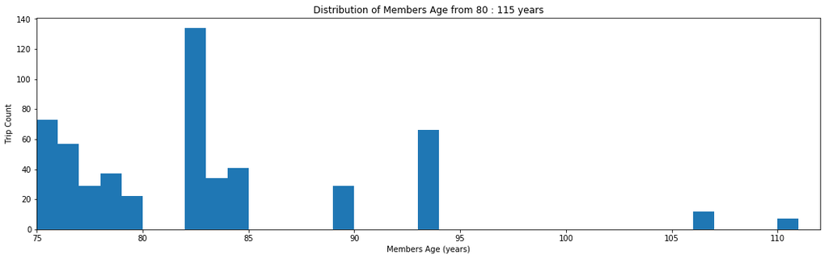

```python
# There is a tail at the right end between 75 and 112 years, so lets spot it
binsize = 1
bins = np.arange(75, 112+binsize, binsize)

plt.figure(figsize=[18, 5])
plt.hist(data = gobike, x = 'member_age_2017', bins = bins)
plt.xlim(75, 112)
plt.xlabel('Members Age (years)')
plt.ylabel('Trip Count')
plt.title('Distribution of Members Age from 80 : 115 years');
```

## Members Gender Trips

There are entries with unspecified genders I excluded it. A High space between male members trips and female members ones.

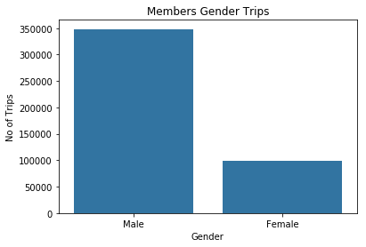

```python
# Plot a the Members Gender Trips (excluding 'Other' group from member_gender group)
sb.countplot(data=gobike, x='member_gender', order=gobike.member_gender.value_counts().iloc[:2].index
             ,color=sb.color_palette()[0])
plt.xlabel('Gender')
plt.ylabel('No of Trips')
plt.title('Members Gender Trips');
```

## Distribution of DayHours

The Distribution shape of day hours has two spikes at both sides with little peak in between. The trips prisk at both (8-9)AM and (5-6)PM (which is rush hours) with moderate activity at mid-day and few activity at the night.

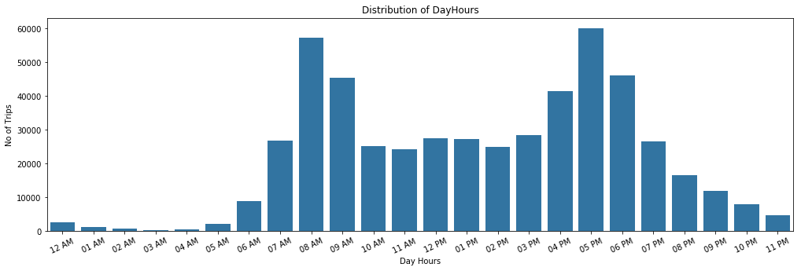

```python
# Bar plot of trips during day hours
plt.figure(figsize=(17,5))
sb.countplot(data=gobike, x='hour', color=sb.color_palette()[0])
plt.xticks(rotation=25)
plt.xlabel('Day Hours')
plt.ylabel('No of Trips')
plt.title('Distribution of DayHours');
```

## Customers and Subscribers activity during Day Hours

Giving the expected activity of trips at rush hours(darkest points), there is much activity in the subscribers side at this hours more than the customers side. In the early hours of the morning and afternoon, subscribers ride the bike on a daily basis more than rest of the day. This may be understood to be due to the reliance on the bike to some subscribers as a means of going to work and back.

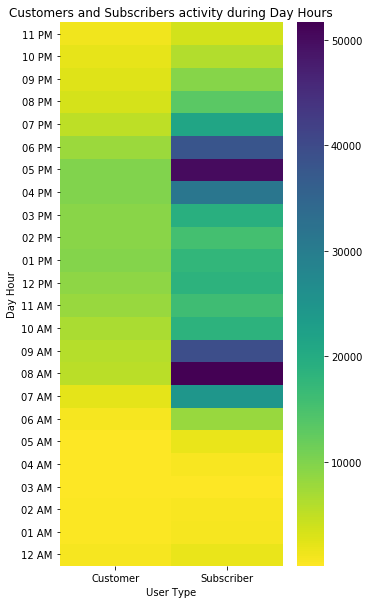

```python
# Plot a heat map of user_type and hour categories veriable
heat_type_counts = gobike.groupby(['user_type', 'hour']).size()
heat_type_counts = heat_type_counts.reset_index(name = 'count')
heat_type_counts = heat_type_counts.pivot(index = 'hour', columns = 'user_type', values = 'count')
plt.figure(figsize=(5, 10))
ax = sb.heatmap(heat_type_counts, cmap='viridis_r')
plt.yticks(rotation=0)
plt.xlabel('User Type')
plt.ylabel('Day Hour')
plt.title('Customers and Subscribers activity during Day Hours')
ax.invert_yaxis();
```

## Overall Ridership by Month

Biking ridership begin to increase in a monthly manner with summer months until the end of the summer (September) and then begin to decrease thereafter with autumn months. This may be due to the nature of the weather.

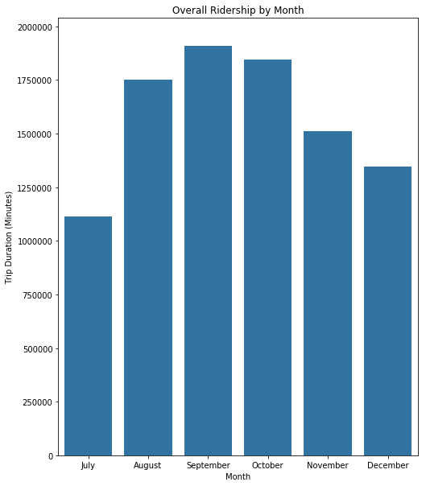

```python
# Plot bar plot of trip durations among months (excluding June data due to incompelete of its data)
plt.figure(figsize=[8, 10])
sb.barplot(data=gobike, x='month', y='duration_min', color = sb.color_palette()[0],
           errwidth=0, estimator=sum)
plt.xlabel('Month')
plt.ylabel('Trip Duration (Minutes)')
plt.title('Overall Ridership by Month');
```

## Weekdays Average Ridership

By the same way there is a space between the ridership during weekends and the ridership during workdays.

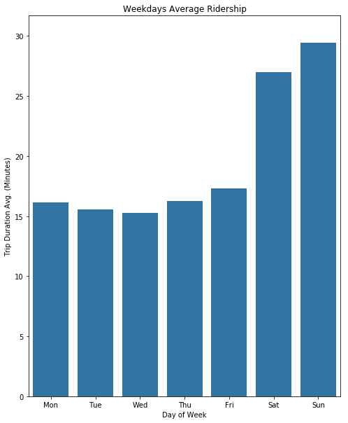

```python
# Plot bar plot of  average trip durations among weekdays
plt.figure(figsize=[8, 10])
sb.barplot(data=gobike, x='weekday', y='duration_min', color = sb.color_palette()[0],
          errwidth=0)
plt.xlabel('Day of Week')
plt.ylabel('Trip Duration Avg. (Minutes)')
plt.title('Weekdays Average Ridership');
```

## Trip Duration Vs. Member Age

It is clear that the relationship between the age of the members and duration of the trip is negative. The older the age, the shorter the trip and vice versa. It is noted that there is an intensity in short trips less than 20 minutes and also there is a density of trips among the young people under the age of 40 years.

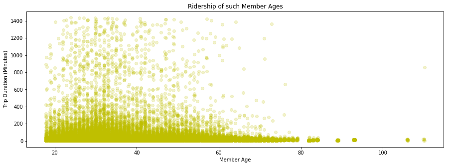

```python
# Plot a scatter plot of trip durations and member ages
plt.figure(figsize=[15, 5])
gobike_filtered = gobike[gobike['member_age_2017'] > 0]
sb.regplot(data= gobike_filtered, x='member_age_2017', y='duration_min',
           scatter_kws={'alpha':1/5}, fit_reg=False, x_jitter=0.2, y_jitter=0.2, color='y')
plt.xlabel('Member Age')
plt.ylabel('Trip Duration (Minutes)')
plt.title('Ridership of such Member Ages');
```

## Ratio of Subscriber Trips to Customer Trips

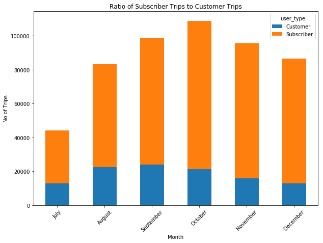

```python
# Plot stacked bar plot of ratio of Subscriber Trips to Customer Trips
groupped = gobike.groupby(['month', 'user_type']).size().reset_index()
groupped = groupped[groupped['month'] != 'June']
groupped = groupped.pivot(index='month', columns='user_type', values=0)
groupped.plot(kind='bar', stacked=True, figsize=(10,7))
plt.xticks(rotation=45)
plt.xlabel('Month')
plt.ylabel('No of Trips')
plt.title('Ratio of Subscriber Trips to Customer Trips');
```

## Trips count of Age Groups in terms of Members Genders'

The users between 31 and 45 years have the most frequency of rent trips for both male and female users. The least frequancy of trips is of users between 80 and 112 years. But in overall, males have more trips frequancy than females.

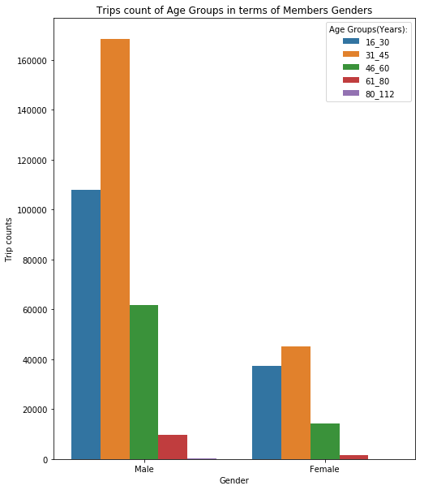

```python
# Plot a clustered bar chart of trip counts with age group in terms of Members Genders (excluding specified gender)
gender_order = gobike.member_gender.value_counts().iloc[:2].index
age_group_order =  ['16_30', '31_45', '46_60', '61_80', '80_112']

plt.figure(figsize=[8, 10])
sb.countplot(data=gobike, x='member_gender', hue='age_group', order=gender_order, hue_order=age_group_order)
plt.title('Trips count of Age Groups in terms of Members Genders')
plt.xlabel('Gender')
plt.ylabel('Trip counts')
plt.legend(title='Age Groups(Years):');
```

## Users Attributes

#### Age, Gender and Type:

The mean of ages of male customers is (33 y) and is near the mean of ages of male subscibers (35 y), and this the case for female customers and female subscribers. Also both of the subscribers genders have wider rang of ages than the customers genders.

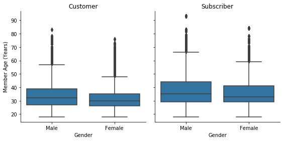

```python
g = sb.FacetGrid(data = gobike, col = 'user_type', size = 4)
g.map(sb.boxplot, 'member_gender', 'member_age_2017', order=
      gobike.member_gender.value_counts().iloc[:2].index)
axes = g.axes.flatten()
axes[0].set_title("Customer")
axes[0].set_xlabel('Gender')
axes[0].set_ylabel('Member Age (Years)')
axes[1].set_title("Subscriber")
axes[1].set_xlabel('Gender');
```

[figure not shown]

```python
## Plot clusterd bar plot of Average Trip durations of Users Age Groups in Months
plt.figure(figsize=(15,8))
ax = sb.barplot(data=gobike, x='month', y='duration_min', hue='age_group',
                errwidth=0, estimator=sum)
plt.xlabel('Month')
plt.ylabel('Avg. Trip Duration(Minutes)')
plt.title('Average Trip durations of Users Age Groups in Months')
plt.legend(title='Age Groups(Years):');
```